# Introduction to corrgrapher

## Example 4 - dragons dataset

In this example, we shall take a look at smaller, artificial dataset containing some information about a population of dragons. It is a useful example, because here we can observe a situation, where correlations are rare.

Once again, let us set up a model, which will predict color of dragon based on the remaining, numerical variables.

```
data(dragons, package='DALEX')
model <- ranger::ranger(colour ~ ., data = dragons, num.trees = 100, probability = TRUE)
model_exp <- DALEX::explain(model, data = dragons[,-5], y = dragons$colour,
                            verbose = FALSE)

dragons_cgr <- corrgrapher(
  model_exp,
  feature_importance = list(loss_function = DALEX::loss_accuracy,
                                 type = 'raw')
)
```

```
dragons_cgr
```

[interactive chart not shown]

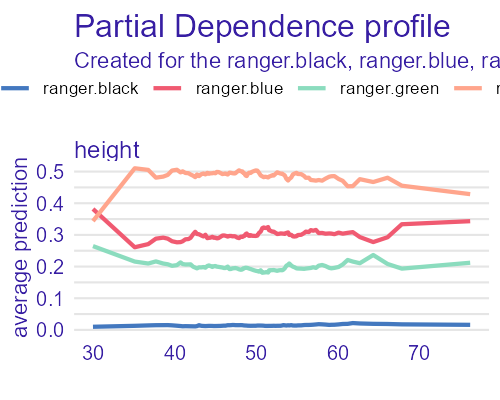

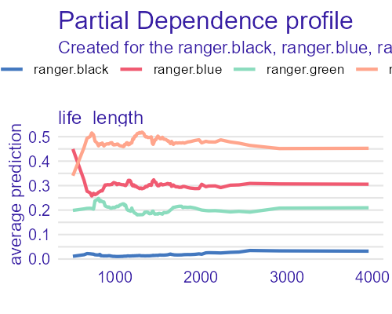

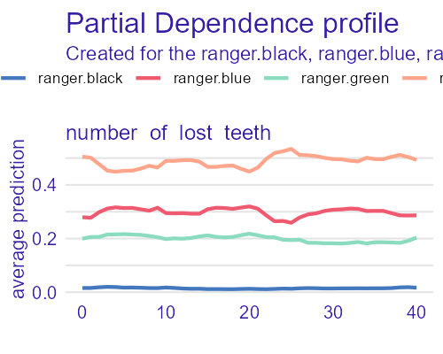

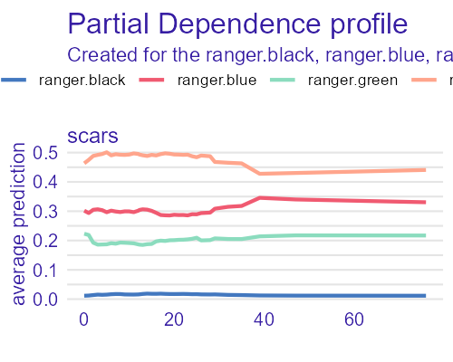

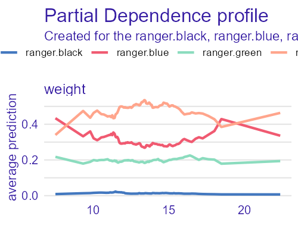

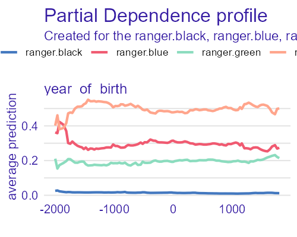

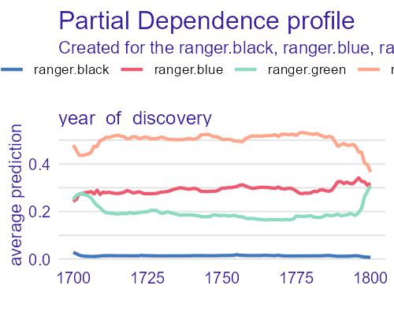

Here we see, that the variables are mostly **not** correlated. We identify all correlations instantly:

- `height` and `weight`
- `scars` and `life_length`
- `number_of_lost_teeth` and `life_length` .

## HTML Report

If you wish to save info about single `corrgrapher` object, use `save_to_html()` function:

```
## NOT RUN
save_to_html(fifa_cgr)
```

It will produce a HTML file, containing a similar output the one from chunks above.

## See also

[Customization](https://modeloriented.github.io/corrgrapher/articles/Customization.html) vignette covering supplying options to functions.